# Module 01: In-Class Exercise

Ethan Gutknecht

1/27/2022

#### HEADER 4: **Task 1:** Changing The Header Size, bold, and italics **(5 Points)**

### HEADER 3: **Task 1:** Changing The Header Size, bold, and italics **(5 Points)**

## HEADER 2: **Task 1:** Changing The Header Size, bold, and italics **(5 Points)**

# HEADER 1: **Task 1:** Changing The Header Size, bold, and italics **(5 Points)**

**BOLD TEXT: This is STA333 class.**

*ITALIC TEXT: This is STA333 class.*

#### **Task 2:** Writing the most commonly used statistical symbols. **(10 Points)**

Population Mean: $\mu$

Population proportion: *p*

Population standard deviation: $\sigma$

Level of significance equal 0.05: $\alpha = 0.05$

p-value: $p$-value

Chi-square distribution with three degrees of freedom: $\chi$ <sup>2</sup><sub>(3)</sub>

#### **Task 3:** Writing the null and alternative hypotheses. **(55 Points)**

$H_{0}$: *M* = 4 Miles

$H_{a}$: *M* $\neq$ 4 Miles

$H_{0}$: *M* < 4 Miles

$H_{0}$: *p* = 0.85

$H_{a}$: *p* $\neq$ 0.85

$H_{0}$: *p* > 0.85

$H_{0}$: $M_{1}$ = $M_{2}$

$H_{a}$: $M_{1}$ $\neq$ $M_{2}$

$H_{0}$: $M_{1}$ < $M_{2}$

$H_{0}$: $\rho$ = 0

$H_{a}$: $\rho \neq$ 0

$H_{0}$: $\rho$ > 0

$H_{0}$: $\tau$ = 0

$H_{a}$: $\tau$ $\neq$ 0

$H_{0}$: $\tau$ < 0

$H_{0}$: $\sigma_{1}$ = $\sigma_{2}$

$H_{a}$: $\sigma_{1}$ $\neq$ $\sigma_{2}$

$H_{0}$: $\sigma_{1}$ > $\sigma_{2}$

#### **Task 4:** Formatting texts **(5 Points)**

*t*-test

`t-test`

Chi-square test

`Chi-square test`

Kruskal-Wallis test

`Kruskal-Wallis test`

#### **Task 5:** Installing R packages **(5 Points)**

Console Output from (coin) package:  
package ‘zoo’ successfully unpacked and MD5 sums checked package ‘TH.data’ successfully unpacked and MD5 sums checked package ‘sandwich’ successfully unpacked and MD5 sums checked package ‘libcoin’ successfully unpacked and MD5 sums checked package ‘modeltools’ successfully unpacked and MD5 sums checked package ‘multcomp’ successfully unpacked and MD5 sums checked package ‘coin’ successfully unpacked and MD5 sums checked

#### **Task 6:** Creating a data vector **(10 Points)**

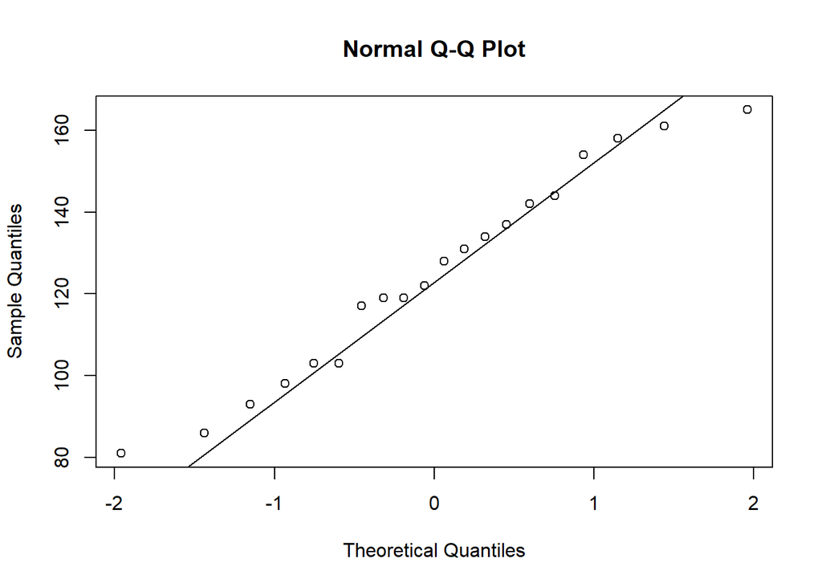

```r
Ethan <- c(142, 103, 86, 165, 134, 154, 119, 81, 98, 122, 161, 117,119, 93, 144, 128, 131, 137, 158, 103)

qqnorm(Ethan)
qqline(Ethan)
```

#### **Task 7:** Reading in a CSV file on R **(10 Points)**

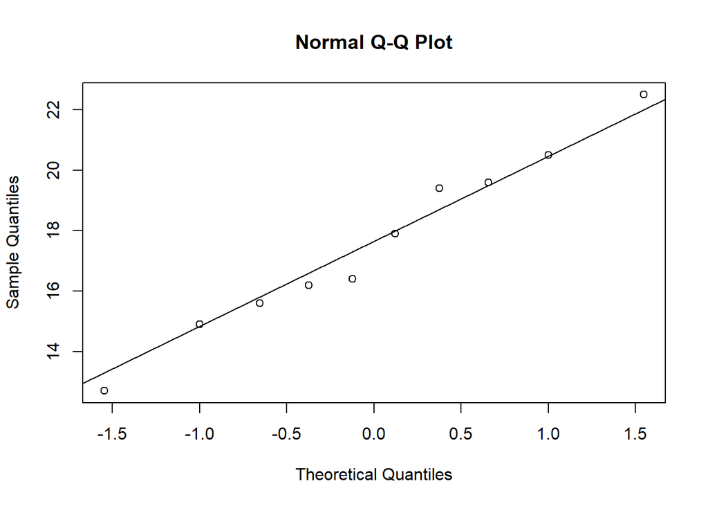

```r
# Read from CSV file
CSVData <- read.csv("Engine.csv", header = TRUE)

qqnorm(CSVData$Emission)
qqline(CSVData$Emission)
```